# New Feature Idea: Order Diversity

I just had an interesting idea for a new feature that might be related to the probability of reordering.

I call it order diversity and it is the percentage of products in an order that are from different aisles / departments. The idea is that the more diverse a first order is, the less likely products are going to be reordered on the next order.

Let’s explore this possibility in this kernel:

### Read in the data

```r
library(data.table)
library(dplyr)
library(ggplot2)

orders <- fread('../input/orders.csv')
products <- fread('../input/products.csv')
order_products_prior <- fread('../input/order_products__prior.csv')
```

As the number of items in an order is for sure correlated with the order diversity, I focus on orders with the same number of products to calculate diversity. As orders with 5 products are most common, let’s examine those.

So, we first select all first orders containing 5 products and calculate order diversity for those. Then, we can take each corresponding second order and examine the probability of reordering.

This procedure can of course be done for other numbers of products and also for example for the last prior order and evaluated on the train order.

#### Do the calculations

```r
order_ids <- order_products_prior %>%
  group_by(order_id) %>%
  tally() %>%
  filter(n==5) %>%
  left_join(orders,by="order_id") %>%
  filter(order_number == 1) %>%
  .$order_id

order1 <- order_products_prior %>%
  filter(order_id %in% order_ids) %>%
  left_join(products,by="product_id") %>%
  group_by(order_id) %>%
  summarize(order_diversity_aisles = length(unique(aisle_id))/n(), order_diversity_department = length(unique(department_id))/n()) %>%
  left_join(orders, by="order_id")

order2 <- orders %>%
  filter(order_number==2) %>%
  left_join(order_products_prior, by="order_id") %>%
  group_by(user_id) %>%
  summarize(mean_reordered=mean(reordered))

tmp <- order1 %>% left_join(order2,by="user_id")
```

#### Plot the effect

##### Aisle Diversity

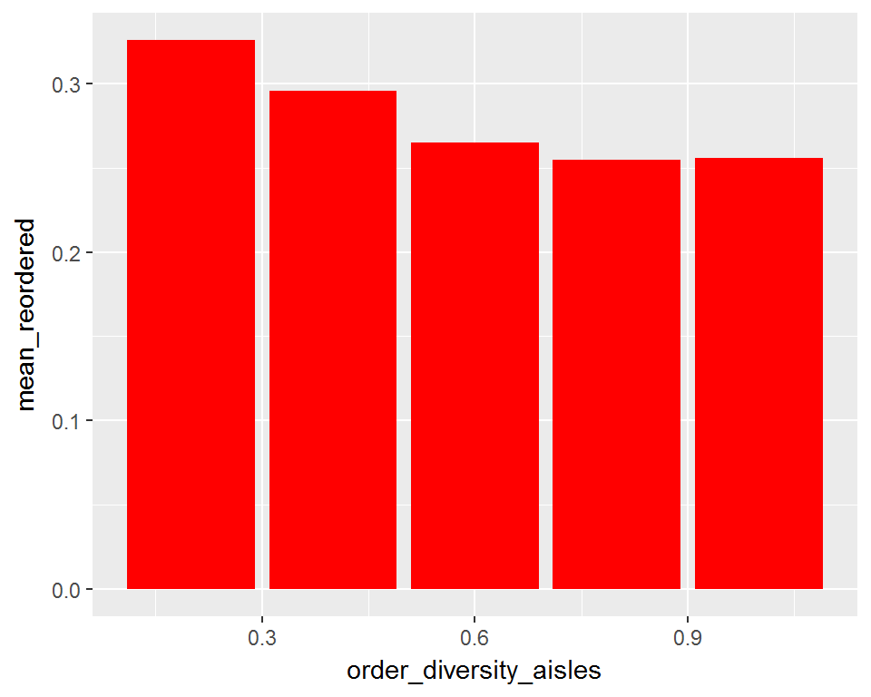

```r
tmp %>% group_by(order_diversity_aisles) %>%
  summarize(mean_reordered=mean(mean_reordered)) %>%
  ggplot(aes(x=order_diversity_aisles,y=mean_reordered)) + geom_bar(stat="identity", fill="red")
```

##### Department Diversity

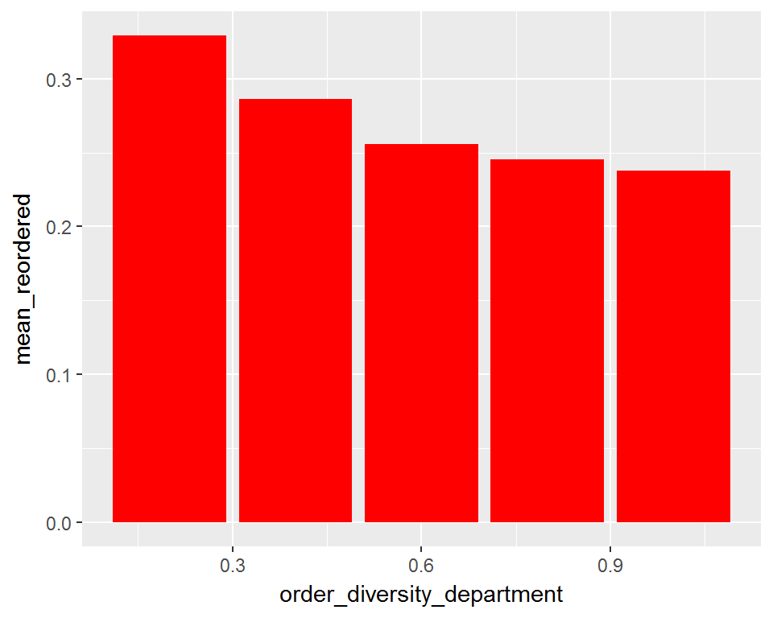

```r
tmp %>% group_by(order_diversity_department) %>%
  summarize(mean_reordered=mean(mean_reordered)) %>%
  ggplot(aes(x=order_diversity_department,y=mean_reordered)) + geom_bar(stat="identity", fill="red")
```

So in fact it appears to be true. The more diverse the first order the lower the probability of reordered items in the followin order.

### Is this a general effect?

It would be interesting to know whether this holds for more numbers of products:

#### For 7 products in an order

##### Aisle Diversity

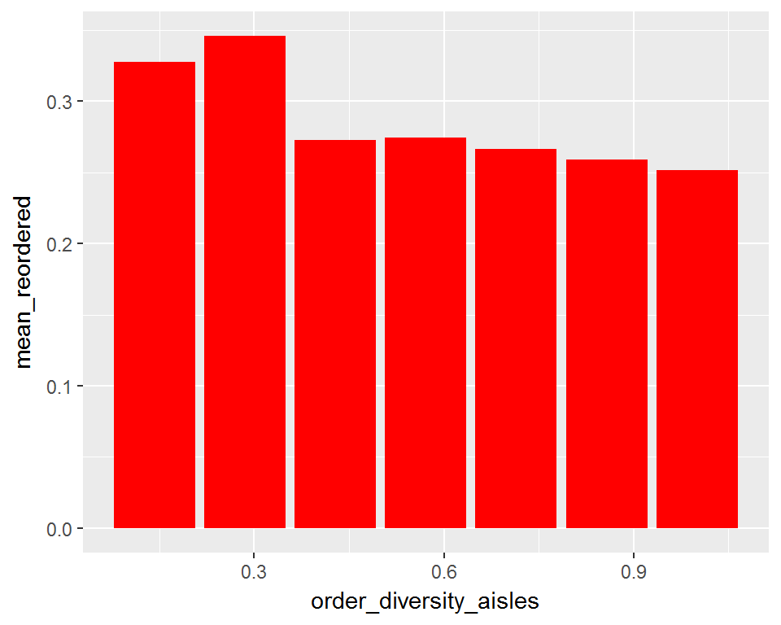

##### Department Diversity

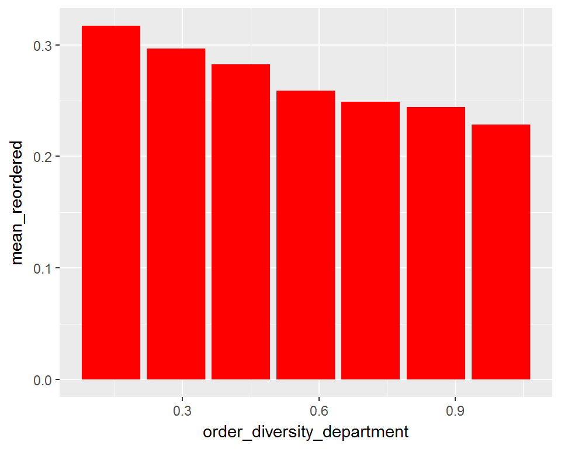

#### For 10 products in an order

##### Aisle Diversity

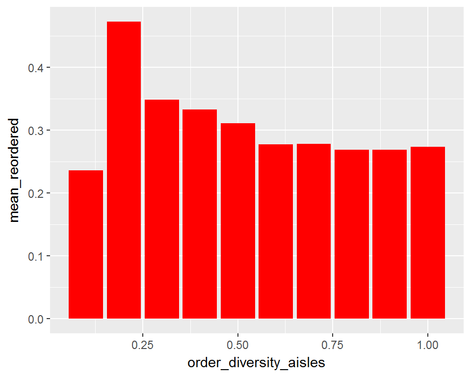

##### Department Diversity

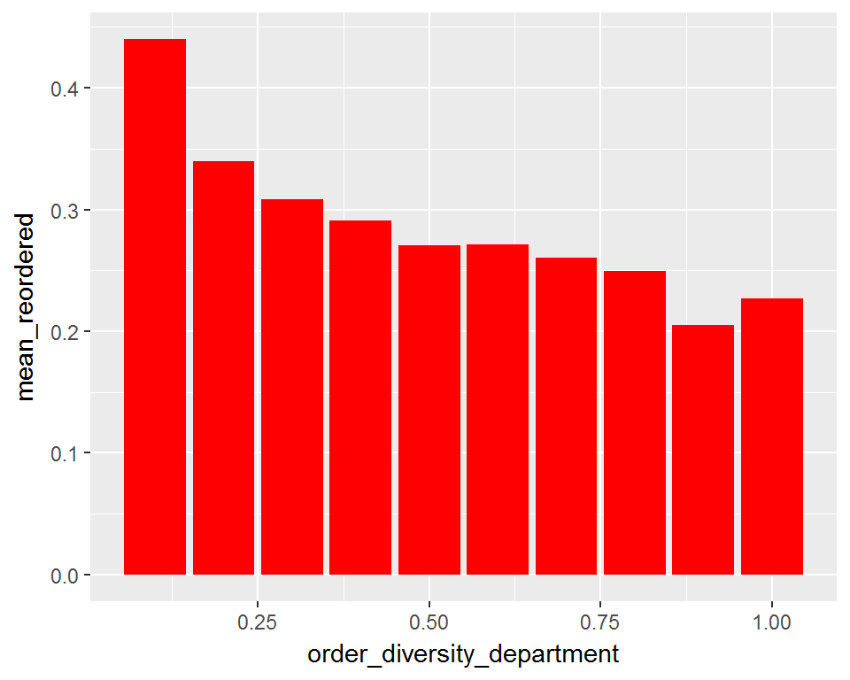

### For different orders

It would be interesting to know whether this also holds for other orders, such as the 2nd and 3rd:

#### 2nd and 3rd

##### Aisle Diversity

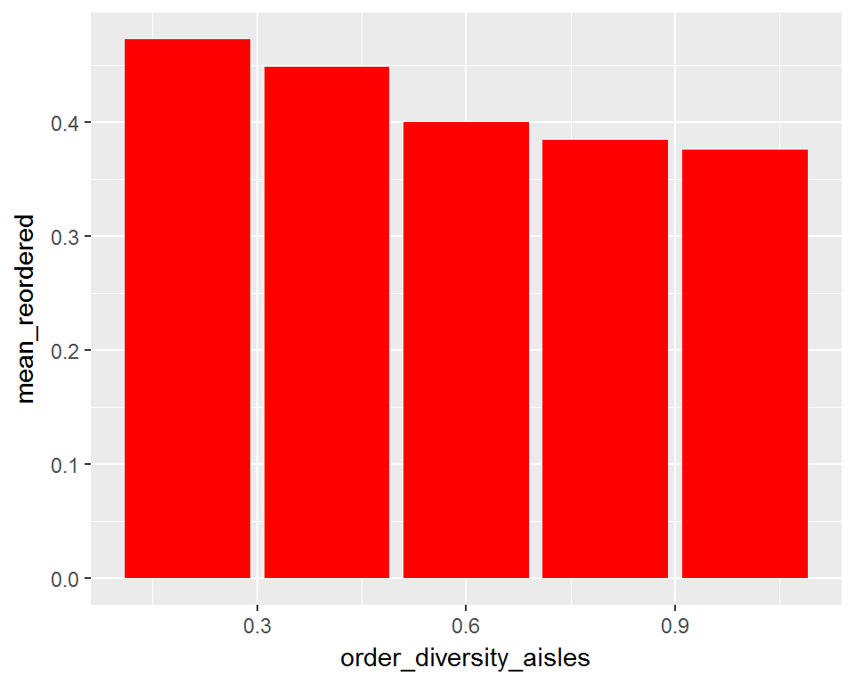

##### Department Diversity

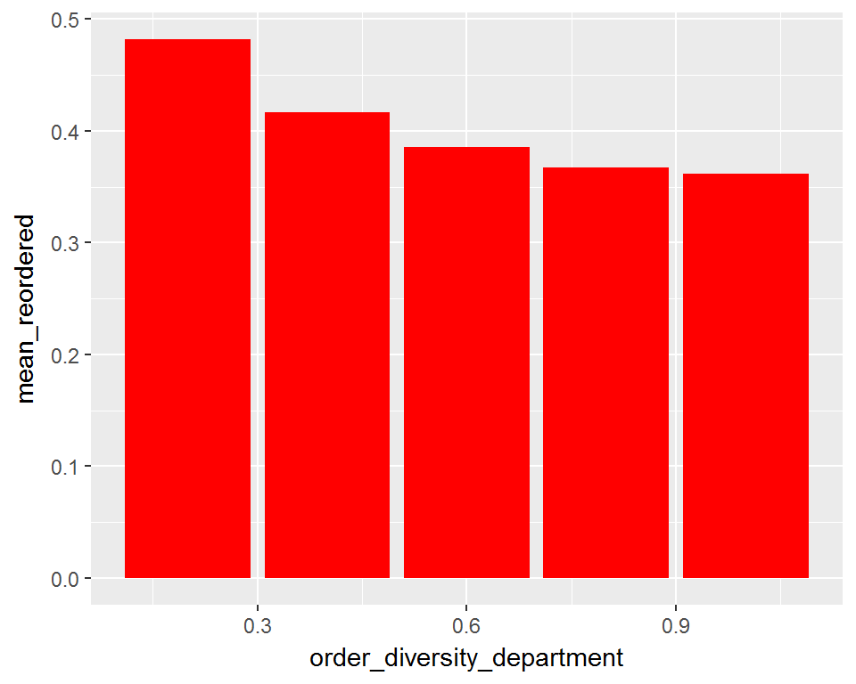

#### 3rd and 4th

##### Aisle Diversity

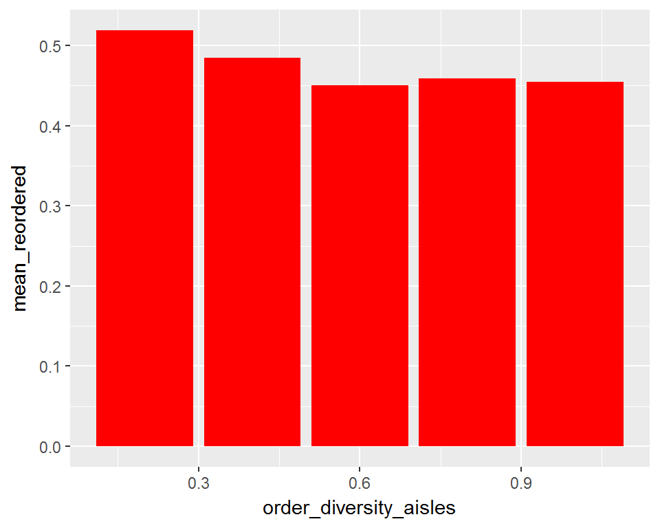

##### Department Diversity

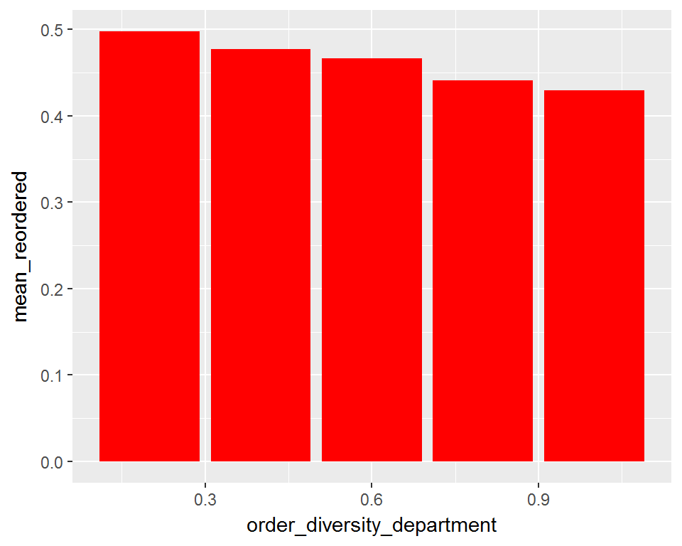

#### This really looks like an interesting feature. What do you think?